# 1000 Companies Profit Prediction Model

Author

Isaac Njuguna

Published

October 29, 2026

## 1 Project overview

When launching a new venture or allocating capital in an existing business, optimizing resource allocation across functional departments—such as Research & Development, Administration, and Marketing—is critical to maximizing return on investment. This project leverages data-driven insights and historical financial records from 1,000 corporate entities to model the underlying mathematical relationships between departmental expenditure, geographic location, and net profitability. By training a predictive regression model on this dataset, the project provides a reliable forecasting tool to estimate expected profits based on planned budget distributions.

## 3 Project objective

This project is to conduct a end-to-end data science workflow to analyze operational expenditure patterns and accurately forecast company profitability.

## 4 1. Import Libraries & Setup

In this section, we import the essential Python libraries required for data manipulation, exploratory data analysis, and machine learning modeling.

```python
#case implementation of linear regression
#1)importing libraries
import numpy as np
import matplotlib.pyplot as plt
import pandas as pd
import seaborn as sns
#tools needed to convert text into numbers
from sklearn.preprocessing import LabelEncoder,OneHotEncoder
from sklearn.compose import ColumnTransformer
from sklearn.model_selection import train_test_split
from sklearn.linear_model import LinearRegression
from sklearn.metrics import r2_score
import statsmodels.api as sm
%matplotlib inline
```

## 5 2.Loading the data

In this step,we tell Python exactly where to find our file on the computer and open. Then we split our data into two groups:the inputs(everything the company spends money on i.e R&D and marketing) and the output (the final profit we want to predict).We also take a quick look at the first few rows to make sure everything is loaded .

```python
#load the dataset and extract the independent and dependent variables
file_path="data/1000_Companies.csv"

# 3. Load the dataset into pandas
companies = pd.read_csv(file_path)

# 4. Extract independent (x) and dependent (y) variables
#select all rows except the last column and convert the selected pandas dataframe to numpy array(independent var)
x = companies.iloc[:, :-1].values
#depedent var(y) select all rows and column at index 4
y = companies.iloc[:, 4].values

# 5. Preview the dataframe
companies.head()
```

|  | R&D Spend | Administration | Marketing Spend | State | Profit |
| --- | --- | --- | --- | --- | --- |
| 0 | 165349.20 | 136897.80 | 471784.10 | New York | 192261.83 |
| 1 | 162597.70 | 151377.59 | 443898.53 | California | 191792.06 |
| 2 | 153441.51 | 101145.55 | 407934.54 | Florida | 191050.39 |
| 3 | 144372.41 | 118671.85 | 383199.62 | New York | 182901.99 |
| 4 | 142107.34 | 91391.77 | 366168.42 | Florida | 166187.94 |

## 6 3.univariate analysis

we evaluates each variable in isolation to understand its central tendency, spread, distribution shape, and presence of outliers.

```python
#Data Types Check
print(companies.dtypes)
```

```
R&D Spend          float64
Administration     float64
Marketing Spend    float64
State                  str
Profit             float64
dtype: object
```

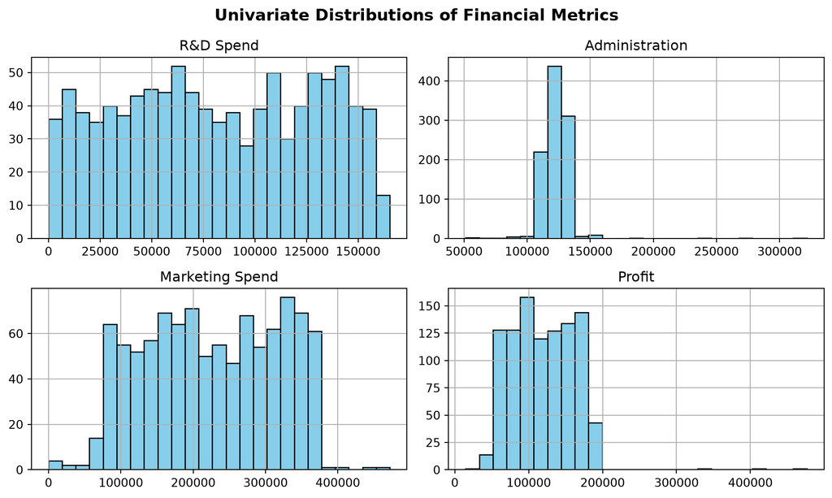

```python
#histogram for all numerical columns
companies.hist(bins=25, figsize=(10, 6), color='skyblue', edgecolor='black')
plt.suptitle('Univariate Distributions of Financial Metrics', fontsize=14, fontweight='bold')
plt.tight_layout()
plt.show()
```

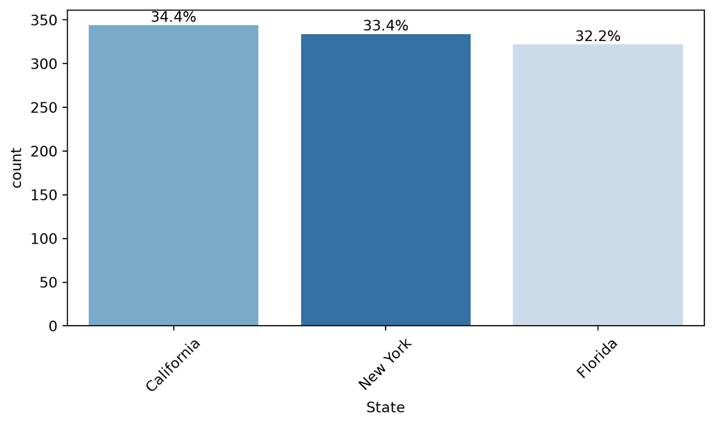

```python
##Categorical variables(state)
#Sorted count plot for State distribution
plt.figure(figsize=(8, 4))
ax = sns.countplot(
    data=companies,
    x='State',
    order=companies['State'].value_counts().index,
    hue='State',
    palette='Blues_r',
    legend=False,
)
plt.xticks(rotation=45)

# Quick percentage annotation loop
for p in ax.patches:
    if (h := p.get_height()) > 0:
        ax.annotate(
            f'{h / len(companies) * 100:.1f}%',
            (p.get_x() + p.get_width() / 2, h),
            ha='center',
            va='bottom',
        )

plt.show()
```

This sorted bar chart reveals which states hold the highest concentration of companies in our dataset, ensuring we are aware of any geographic bias in our sample.

## 7 4.Bivariate analysis

bivariate analysis explores the relationships and interactions between pairs of variables.

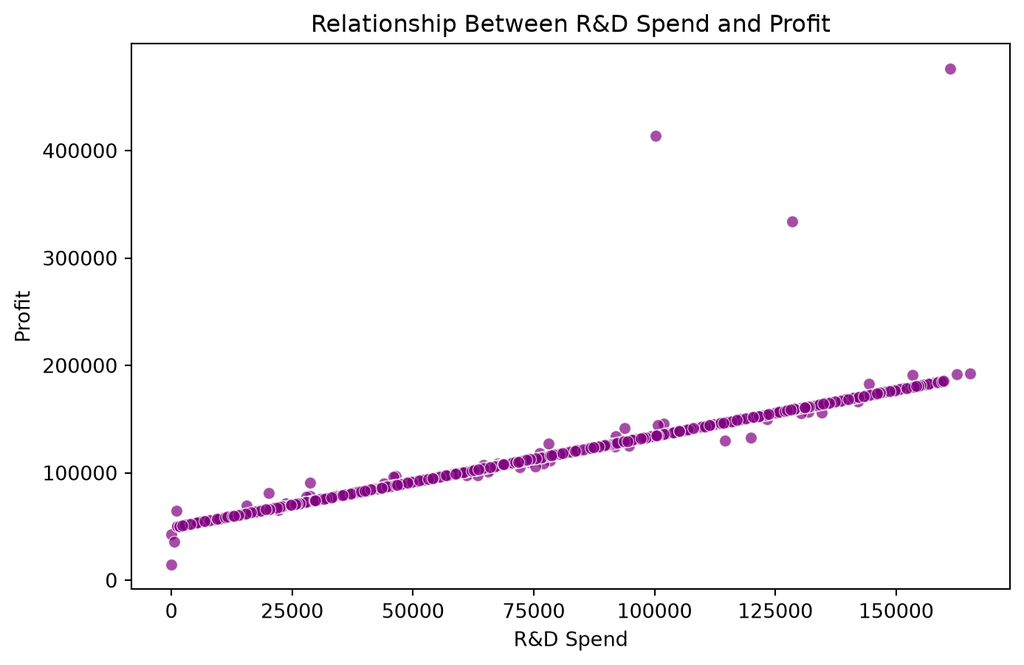

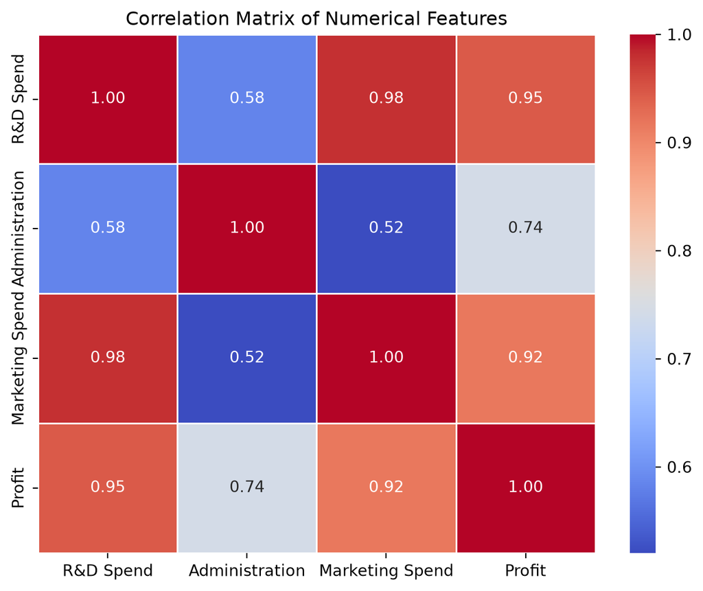

```python
#numeric var
#Scatter plot: R&D Spend vs. Profit
plt.figure(figsize=(8, 5))
sns.scatterplot(
    data=companies, x='R&D Spend', y='Profit', color='purple', alpha=0.7
)
plt.title('Relationship Between R&D Spend and Profit')
plt.xlabel('R&D Spend')
plt.ylabel('Profit')
plt.show()

# 2. Correlation Heatmap (Fixed by selecting only numerical columns)
plt.figure(figsize=(8, 6))
numeric_companies = companies.select_dtypes(
    include=['number']
)  # Ignores text columns like State
sns.heatmap(numeric_companies.corr(),annot=True,cmap='coolwarm',fmt='.2f',linewidths=0.5,)
plt.title('Correlation Matrix of Numerical Features')
plt.show()
```

N/B: ~The scatter plot show a strong positive linear trend;means that companies that invest more in R&D tend to secure significantly higher profits ~the correlation matrix highlights which spending category has the strongest linear tie to financial return

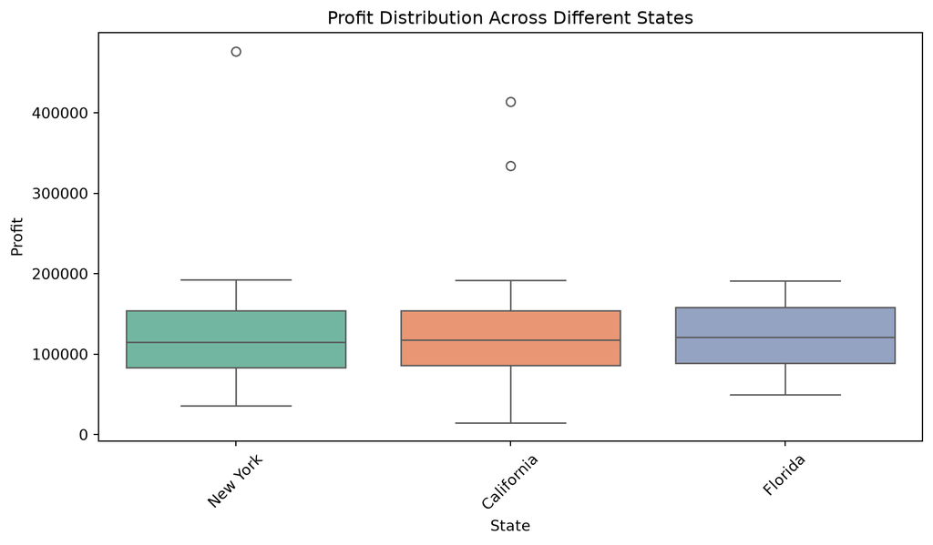

```python
#categorical&numerical(state vs profit
# Boxplot comparing Profit across different States
plt.figure(figsize=(10, 5))
sns.boxplot(data=companies, x='State', y='Profit', hue='State', palette='Set2', legend=False)
plt.title('Profit Distribution Across Different States')
plt.xlabel('State')
plt.ylabel('Profit')
plt.xticks(rotation=45)
plt.show()
```

## 8 5.Multivariate analysis

we examine the combined impact of multiple independent variables on our target variable.

```python
# Preparing data for OLS Regression
X = companies[['R&D Spend', 'Administration', 'Marketing Spend']]
X = sm.add_constant(X)  # Adds intercept
y = companies['Profit']

# Fit Ordinary Least Squares (OLS) model
model = sm.OLS(y, X).fit()
print(model.summary())
```

```
                            OLS Regression Results
==============================================================================
Dep. Variable:                 Profit   R-squared:                       0.950
Model:                            OLS   Adj. R-squared:                  0.950
Method:                 Least Squares   F-statistic:                     6290.
Date:                Sun, 01 Nov 2026   Prob (F-statistic):               0.00
Time:                        01:14:25   Log-Likelihood:                -10588.
No. Observations:                1000   AIC:                         2.118e+04
Df Residuals:                     996   BIC:                         2.120e+04
Df Model:                           3
Covariance Type:            nonrobust
===================================================================================
                      coef    std err          t      P>|t|      [0.025      0.975]
-----------------------------------------------------------------------------------
const           -7.016e+04   3966.528    -17.687      0.000   -7.79e+04   -6.24e+04
R&D Spend           0.5539      0.035     15.933      0.000       0.486       0.622
Administration      1.0266      0.031     33.066      0.000       0.966       1.088
Marketing Spend     0.0806      0.017      4.790      0.000       0.048       0.114
==============================================================================
Omnibus:                     1578.537   Durbin-Watson:                   1.688
Prob(Omnibus):                  0.000   Jarque-Bera (JB):          1035742.540
Skew:                           9.336   Prob(JB):                         0.00
Kurtosis:                     159.554   Cond. No.                     3.73e+06
==============================================================================

Notes:
[1] Standard Errors assume that the covariance matrix of the errors is correctly specified.
[2] The condition number is large, 3.73e+06. This might indicate that there are
strong multicollinearity or other numerical problems.
```

insights: The OLS Summary provides $p$-values and confidence intervals for each spending category. A $p$-value $< 0.05$ indicates that a specific variable has a statistically significant impact on profit.

## 9 6.Machine learning(predictive model)

```python
# Encoding categorical data
Labelencoder = LabelEncoder()
x[:, 3] = Labelencoder.fit_transform(x[:, 3])

ct = ColumnTransformer(
    transformers=[('encoder', OneHotEncoder(), [3])], remainder='passthrough'
)
x = ct.fit_transform(x)
print(x)
```

```
[[0.0 0.0 1.0 165349.2 136897.8 471784.1]
 [1.0 0.0 0.0 162597.7 151377.59 443898.53]
 [0.0 1.0 0.0 153441.51 101145.55 407934.54]
 ...
 [1.0 0.0 0.0 100275.47 241926.31 227142.82]
 [1.0 0.0 0.0 128456.23 321652.14 281692.32]
 [0.0 0.0 1.0 161181.72 270939.86 295442.17]]
```

N:this prevents the model from assuming a fake ranking order among states

### 9.1 Avoiding the dummy variable trap

here we drop one dummy column to prevent multicollinearity in regression model

```python
x=x[:,1:]
x
```

```
array([[0.0, 1.0, 165349.2, 136897.8, 471784.1],
       [0.0, 0.0, 162597.7, 151377.59, 443898.53],
       [1.0, 0.0, 153441.51, 101145.55, 407934.54],
       ...,
       [0.0, 0.0, 100275.47, 241926.31, 227142.82],
       [0.0, 0.0, 128456.23, 321652.14, 281692.32],
       [0.0, 1.0, 161181.72, 270939.86, 295442.17]],
      shape=(1000, 5), dtype=object)
```

OneHotEncoder() + x = x[:, 1:] manually creates 3 dummy columns and then drops the first one using array slicing.

### 9.2 splitting the data(train&test set)

divide the data into two parts:20% of the data for evaluating the model performance on unseen data & 80% for training the regression model

```python
#rabdom_state=0----makes results reproducible
x_train,x_test,y_train,y_test=train_test_split(x,y,test_size=0.2,random_state=0)
```

### 9.3 Fitting multiple linear regression

initialize and train the linear regression model using the training subset(x_train &y_train)

```python
#create model object
regressor=LinearRegression()
#force the model look at the indepe var(xtrain) and figure out the mathematical formula tht connects them to profit(ytrain)
regressor.fit(x_train,y_train)
```

```
LinearRegression()
```

### 9.4 Predecting the test set results

This step feeds the unseen testing feature (X_test) into our trained linear regression model.Then the model applies its learned mathematical weights (coefficients) to calculate and output an array of forecasted profit values (y_pred) for those companies.

```python
#predecting the test set results
y_pred=regressor.predict(x_test)
y_pred[:20]
```

```
array([ 89790.61532916,  88427.07187361,  94894.67836972, 175680.8672561 ,
        83411.73042089, 110571.90200074, 132145.2293644 ,  91473.37719687,
       164597.05380606,  53222.82667402,  66950.1905099 , 150566.43987004,
       126915.20858596,  59337.85971051, 177513.91053061,  75316.28143051,
       118248.14406603, 164574.40699901, 170937.2898107 , 182069.11645084])
```

insight:When you look at y_pred,you are seeing the model’s best guess of each company’s profit, calculated using only their spending and location which is completely separate from their real financial records.

### 9.5 Calculate the R squared value

Measures the accuracy and goodness of fit of the model by comparing actual profits(y_tests) against the models test profit(y_pred)

```python
r2_score(y_test,y_pred)##successful model
```

```
0.9112695892268834
```

## 10 7.Conclusion

This project successfully transformed raw corporate data into actionable business intelligence. Through thorough univariate and bivariate visualizations, we identified key spending behaviors. Furthermore, our multivariate regression and machine learning pipelines demonstrated that investment choices—particularly in R&D—are exceptionally reliable predictors of corporate profitability, offering clear strategic direction for future budget allocations.